# TCR phospho-signalling upon antibody-based stimulation

Marie Locard-Paulet

Tue Sep 04 17:19:34 2018

Results of enrichment analysis.

`"KEAEnrichments"` contains the results of phosphorylation site specific enrichment using [KEA](http://www.maayanlab.net/KEA2/#) the 4th September 2018 (no background). I saved the enrichment results with the following labels: - “KS” for Literature Based Kinase-Substrate Library with Phosphosites, followed by the cluster number. - “BT” for Biological Terms Associated with Phosphosites from Literature Mining, followed by the cluster number. - “AllReg” is when I used all the regulated sites as input. - “Background” is when I used all the sites identified in the data set.

`"PANTHER"` contains the results of GO term enrichments based on the gene names using [Panther](http://pantherdb.org/) the 4th September 2018. I used the detected sites as background.

`"Phomics"` contains the results of GO term enrichments based on the phosphorylation sites using [Phomics](http://phomics.jensenlab.org/phospho_enrichment_uniprot) the 4th September 2018. I used the detected sites as background.

*The gene list used for the background is in the PANTHER folder.*

# Phomics

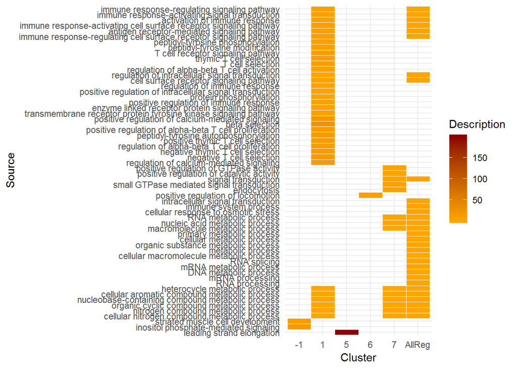

# KEA

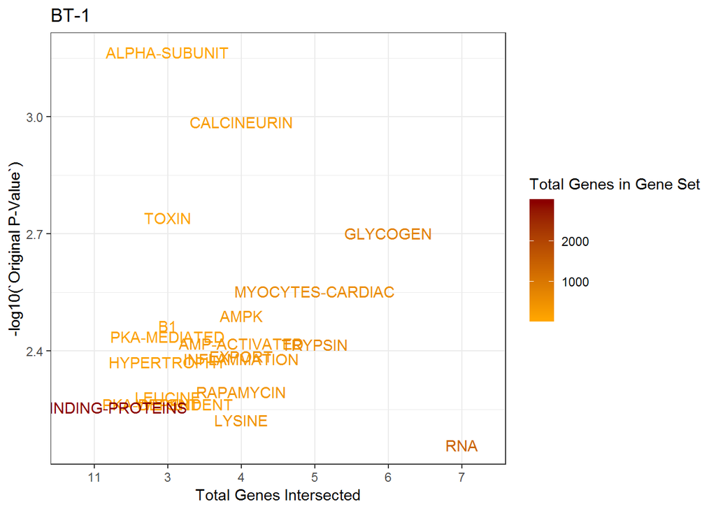

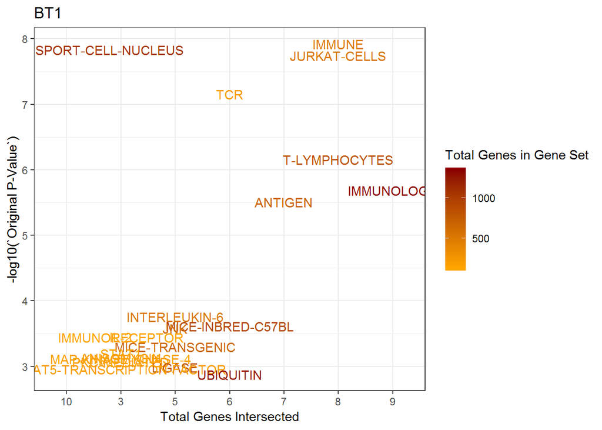

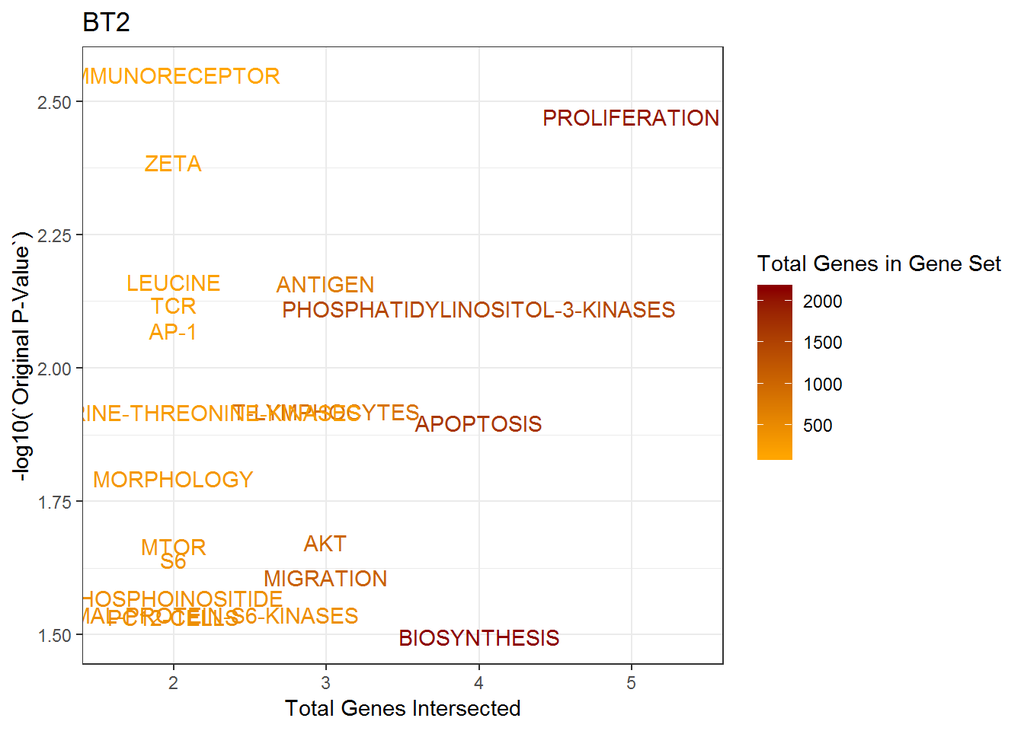

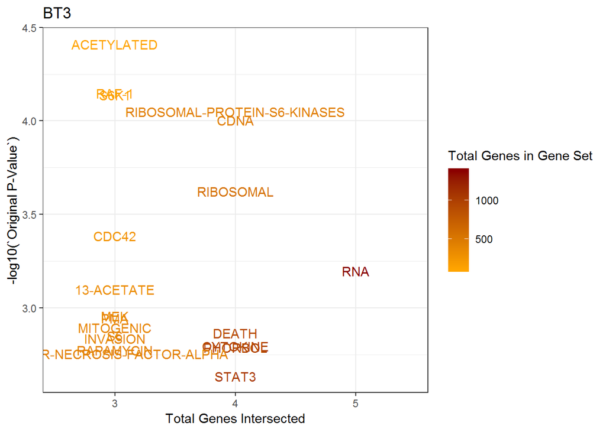

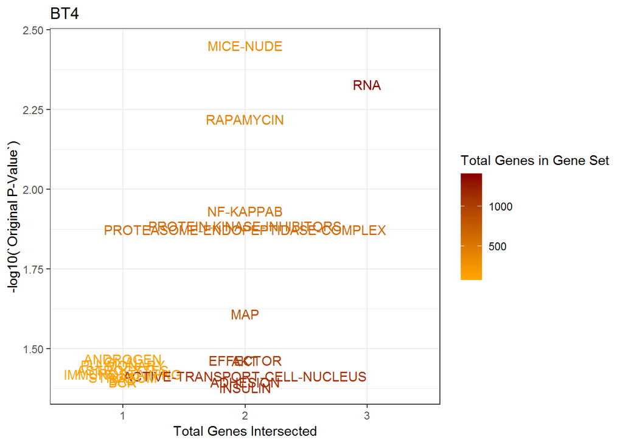

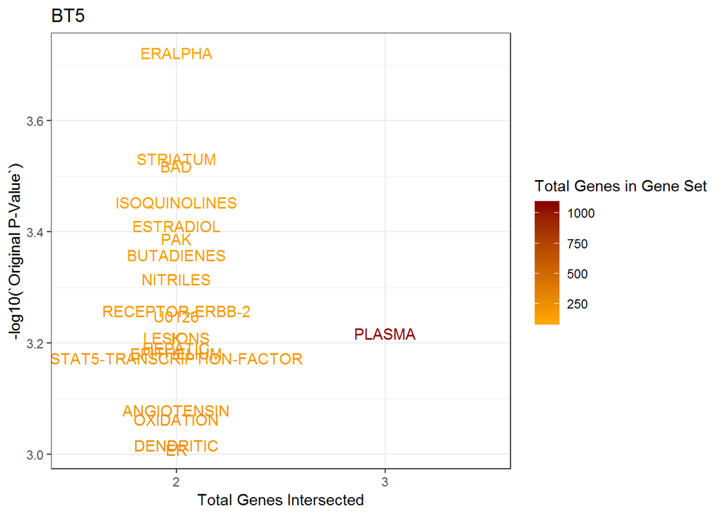

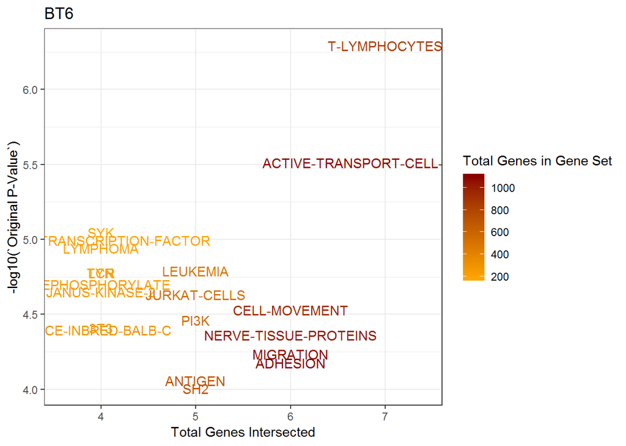

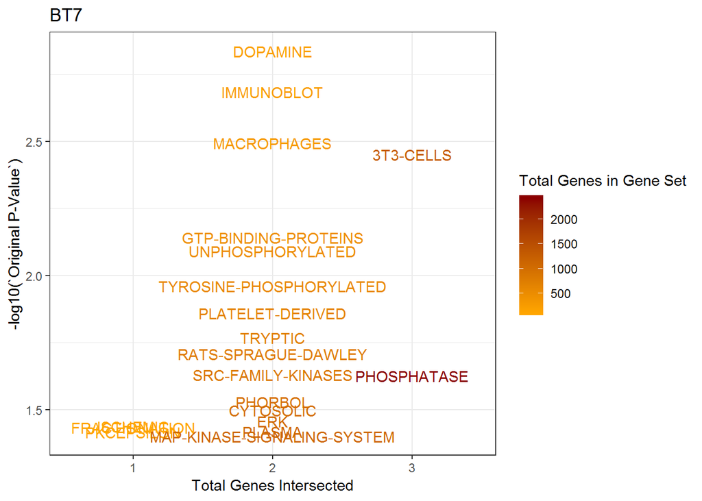

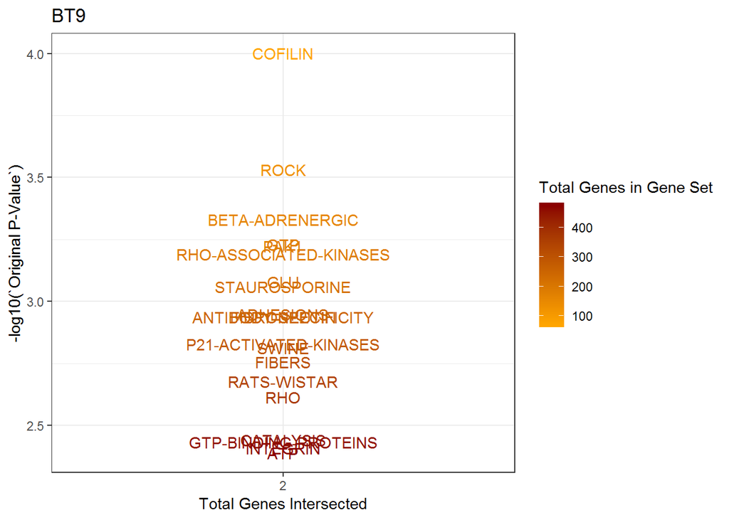

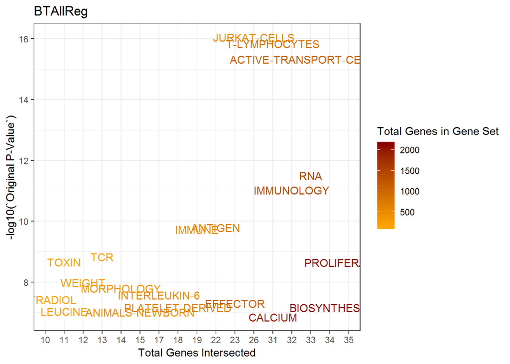

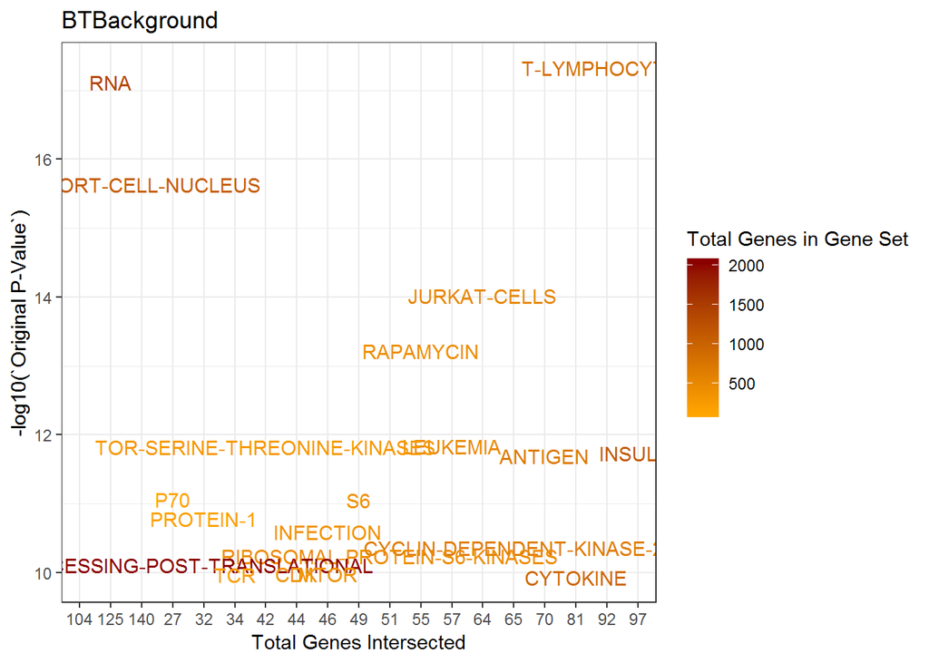

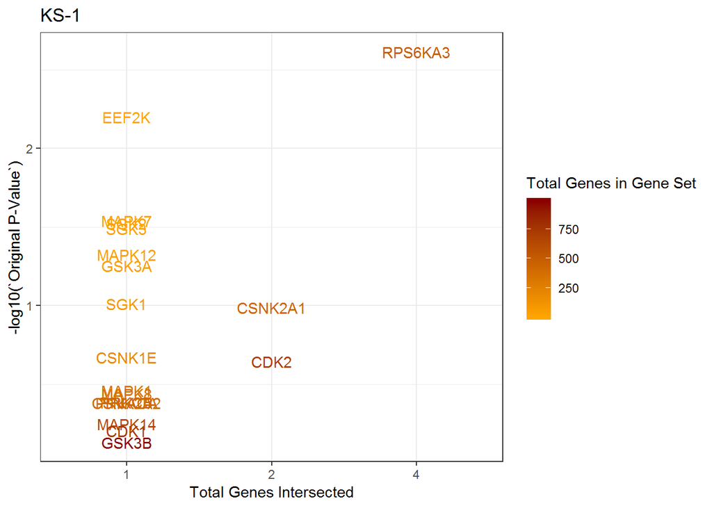

[12 more figures not shown]

# GO term enrichments with Panther

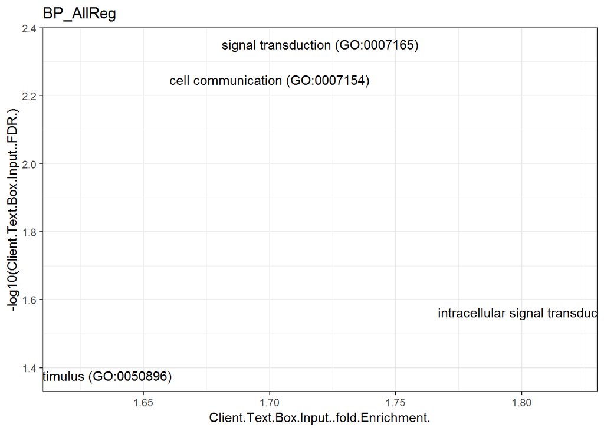

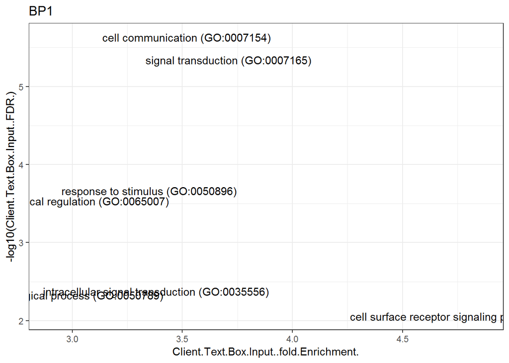

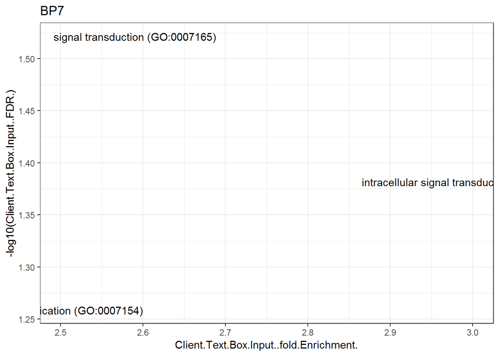

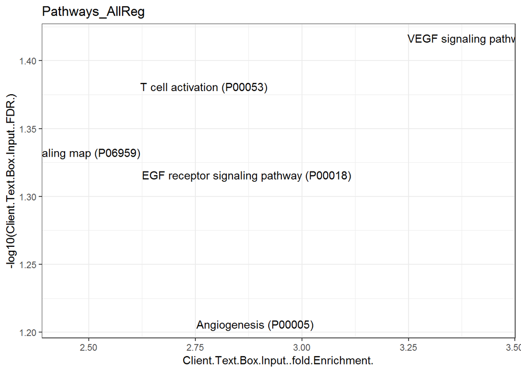

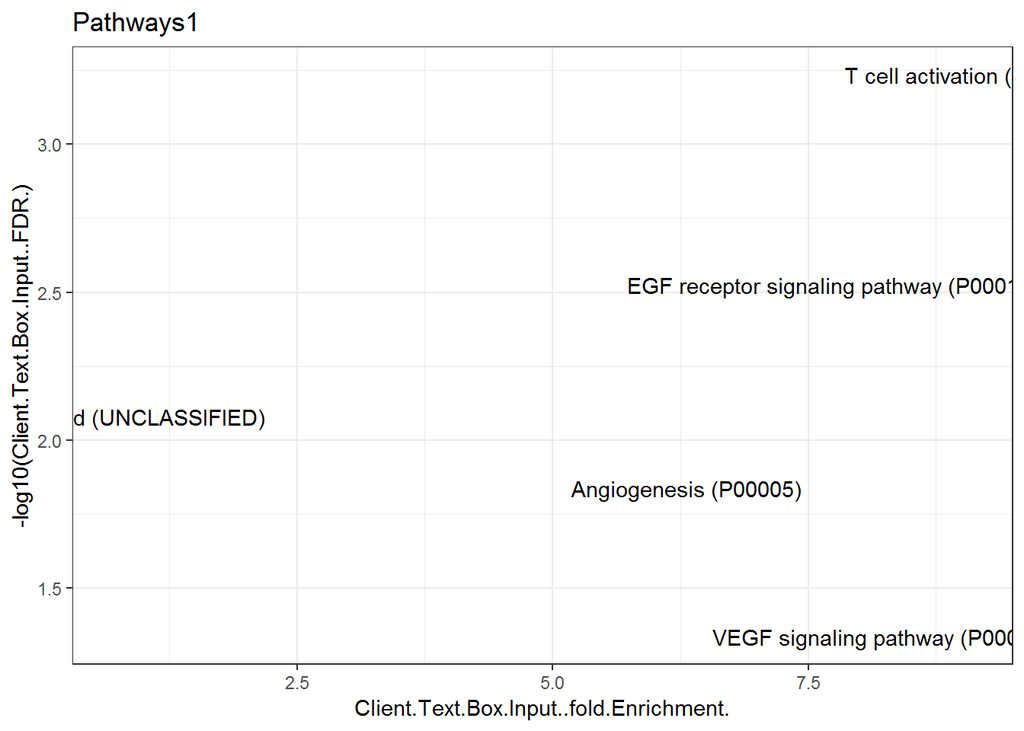

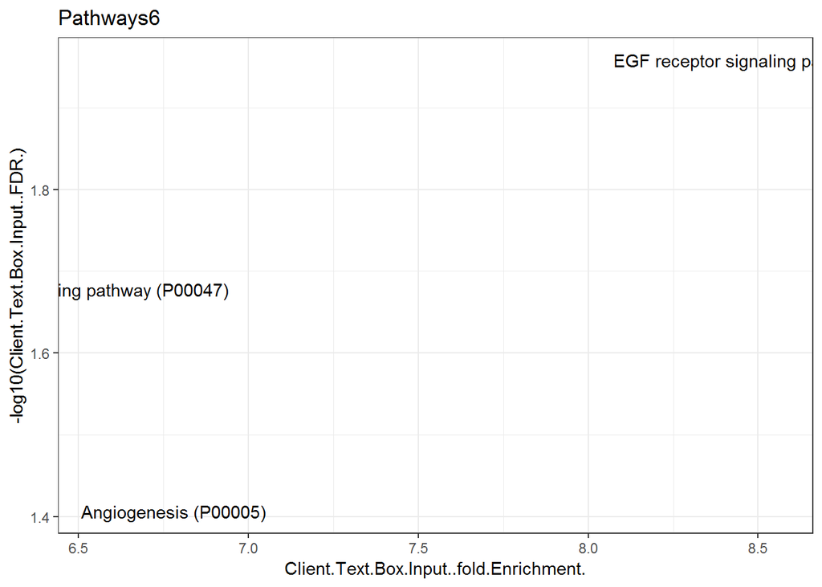